# Introduction to Transcriptomics — Completed Assignment

Puyuan Li

2026-11-09

This notebook completes both parts of the QBIO 490 Week 7 transcriptomics exercise. Run on CARC with access to the existing TCGA-BRCA GDC download. Numerical answers are printed from the actual dataset rather than assumed.

## Part 1 — TCGA RNA-seq data

### Setup and packages

```r
if (!requireNamespace("BiocManager", quietly=TRUE)) install.packages("BiocManager")
required_bioc <- c("TCGAbiolinks", "SummarizedExperiment", "DESeq2", "EnhancedVolcano")
missing_bioc <- required_bioc[!vapply(required_bioc, requireNamespace, logical(1), quietly=TRUE)]
if (length(missing_bioc)) BiocManager::install(missing_bioc, ask=FALSE, update=FALSE)
library(TCGAbiolinks)
library(SummarizedExperiment)
library(DESeq2)
library(EnhancedVolcano)
```

### Load RNA-seq data

The earlier Materials Download assignment downloaded TCGA-BRCA STAR counts. `GDCprepare()` uses the existing local download when it is present. If it reports missing files, uncomment `GDCdownload(rna_query)` and run it once before `GDCprepare()`.

```r
rna_query <- GDCquery(project="TCGA-BRCA",
                      data.category="Transcriptome Profiling",
                      data.type="Gene Expression Quantification",
                      workflow.type="STAR - Counts")
# GDCdownload(rna_query)  # ONLY if the required local GDC files are missing
rna_se <- GDCprepare(rna_query)
```

[output not shown]

[output cut: 1177 more lines]

[output not shown]

```r
stopifnot(inherits(rna_se, "SummarizedExperiment"))
```

### Exercise 1.1 — SummarizedExperiment basics

```r
head(rna_se)
```

```
class: RangedSummarizedExperiment
dim: 6 1231
metadata(1): data_release
assays(6): unstranded stranded_first ... fpkm_unstrand fpkm_uq_unstrand
rownames(6): ENSG00000000003.15 ENSG00000000005.6 ... ENSG00000000460.17 ENSG00000000938.13
rowData names(10): source type ... hgnc_id havana_gene
colnames(1231): TCGA-A8-A09E-01A-11R-A00Z-07 TCGA-A7-A0DC-01A-11R-A00Z-07 ...
  TCGA-EW-A6SA-01A-21R-A32P-07 TCGA-AO-A12B-01A-11R-A10J-07
colData names(94): barcode patient ... paper_PARADIGM Clusters paper_Pan-Gyn Clusters
```

```r
str(rna_se)
```

[output not shown]

[output cut: 2636 more lines]

[output not shown]

### Exercise 1.2 — Dimensions

```r
dim(colData(rna_se))
```

```
[1] 1231   94
```

```r
dim(mcols(rowRanges(rna_se)))
```

```
[1] 60660    10
```

```r
dim(assay(rna_se, "unstranded"))
```

```
[1] 60660  1231
```

```r
cat("colData (rows, columns):", paste(dim(colData(rna_se)), collapse=", "), "\n")
```

```
colData (rows, columns): 1231, 94
```

```r
cat("rowRanges elementMetadata (rows, columns):", paste(dim(mcols(rowRanges(rna_se))), collapse=", "), "\n")
```

```
rowRanges elementMetadata (rows, columns): 60660, 10
```

```r
cat("unstranded (rows, columns):", paste(dim(assay(rna_se, "unstranded")), collapse=", "), "\n")
```

```
unstranded (rows, columns): 60660, 1231
```

### Exercise 1.3 — What do the rows and columns represent?

- **colData:** rows represent sequenced samples (identified by sample barcodes); columns represent clinical and sample metadata variables.
- **rowRanges elementMetadata:** rows represent genes/features; columns describe gene annotations, such as gene IDs and names.
- **unstranded assay:** rows represent the same genes/features as rowRanges; columns represent the same samples, in the same order, as colData. Entries are raw read counts.

```r
head(rownames(colData(rna_se))); colnames(colData(rna_se))
```

```
[1] "TCGA-A8-A09E-01A-11R-A00Z-07" "TCGA-A7-A0DC-01A-11R-A00Z-07" "TCGA-A7-A0DC-11A-41R-A089-07"
[4] "TCGA-A7-A0DC-01B-04R-A22O-07" "TCGA-A8-A08F-01A-11R-A00Z-07" "TCGA-A8-A091-01A-11R-A00Z-07"
 [1] "barcode"                                   "patient"
 [3] "sample"                                    "shortLetterCode"
 [5] "definition"                                "sample_submitter_id"
 [7] "tumor_descriptor"                          "sample_id"
 [9] "pathology_report_uuid"                     "submitter_id"
[11] "sample_type"                               "specimen_type"
[13] "days_to_collection"                        "state"
[15] "initial_weight"                            "tissue_type"
[17] "preservation_method"                       "synchronous_malignancy"
[19] "ajcc_pathologic_stage"                     "days_to_diagnosis"
[21] "laterality"                                "treatments"
[23] "last_known_disease_status"                 "tissue_or_organ_of_origin"
[25] "age_at_diagnosis"                          "primary_diagnosis"
```

[output cut: 34 more lines]

```r
head(rownames(mcols(rowRanges(rna_se)))); colnames(mcols(rowRanges(rna_se)))
```

```
[1] "ENSG00000000003.15" "ENSG00000000005.6"  "ENSG00000000419.13" "ENSG00000000457.14" "ENSG00000000460.17"
[6] "ENSG00000000938.13"
 [1] "source"      "type"        "score"       "phase"       "gene_id"     "gene_type"   "gene_name"
 [8] "level"       "hgnc_id"     "havana_gene"
```

```r
head(rownames(assay(rna_se, "unstranded"))); head(colnames(assay(rna_se, "unstranded")))
```

```
[1] "ENSG00000000003.15" "ENSG00000000005.6"  "ENSG00000000419.13" "ENSG00000000457.14" "ENSG00000000460.17"
[6] "ENSG00000000938.13"
[1] "TCGA-A8-A09E-01A-11R-A00Z-07" "TCGA-A7-A0DC-01A-11R-A00Z-07" "TCGA-A7-A0DC-11A-41R-A089-07"
[4] "TCGA-A7-A0DC-01B-04R-A22O-07" "TCGA-A8-A08F-01A-11R-A00Z-07" "TCGA-A8-A091-01A-11R-A00Z-07"
```

```r
stopifnot(nrow(colData(rna_se)) == ncol(rna_se),
          nrow(mcols(rowRanges(rna_se))) == nrow(rna_se))
```

### Exercise 2.1 — First 15 ages

```r
head(colData(rna_se)$age_at_index, 15)
```

```
 [1] 73 63 63 63 59 61 63 40 56 37 58 62 49 67 56
```

### Exercise 2.2 — Age summary

The minimum, quartiles, mean, maximum and missing-value count below are calculated from the downloaded data; they must not be filled with assumed numbers.

```r
summary(colData(rna_se)$age_at_index)
```

```
   Min. 1st Qu.  Median    Mean 3rd Qu.    Max.     NAs
  26.00   48.00   58.00   58.28   67.00   89.00       1
```

### Exercises 2.3–2.6 — Clinical data cleaning

```r
rna_clinical <- as.data.frame(colData(rna_se))
columns_to_remove <- c("treatments", "primary_site", "disease_type", "sites_of_involvement")
rna_clinical <- rna_clinical[, !(names(rna_clinical) %in% columns_to_remove), drop=FALSE]
# Save the sample-level mask before filtering so it can also subset assay columns.
age_numeric <- suppressWarnings(as.numeric(as.character(rna_clinical$age_at_index)))
age_NA_mask <- !is.na(age_numeric)
rna_clinical <- rna_clinical[age_NA_mask, , drop=FALSE]
rna_clinical$age_at_index <- age_numeric[age_NA_mask]
summary(rna_clinical$age_at_index)
```

```
   Min. 1st Qu.  Median    Mean 3rd Qu.    Max.
  26.00   48.00   58.00   58.28   67.00   89.00
```

```r
stopifnot(!anyNA(rna_clinical$age_at_index))
```

### Exercises 3.1–3.3 — Gene information

```r
head(mcols(rowRanges(rna_se)))
```

```
DataFrame with 6 rows and 10 columns
                     source     type     score     phase            gene_id      gene_type   gene_name
                   <factor> <factor> <numeric> <integer>        <character>    <character> <character>
ENSG00000000003.15   HAVANA     gene        NA        NA ENSG00000000003.15 protein_coding      TSPAN6
ENSG00000000005.6    HAVANA     gene        NA        NA  ENSG00000000005.6 protein_coding        TNMD
ENSG00000000419.13   HAVANA     gene        NA        NA ENSG00000000419.13 protein_coding        DPM1
ENSG00000000457.14   HAVANA     gene        NA        NA ENSG00000000457.14 protein_coding       SCYL3
ENSG00000000460.17   HAVANA     gene        NA        NA ENSG00000000460.17 protein_coding    C1orf112
ENSG00000000938.13   HAVANA     gene        NA        NA ENSG00000000938.13 protein_coding         FGR
                         level     hgnc_id          havana_gene
                   <character> <character>          <character>
ENSG00000000003.15           2  HGNC:11858 OTTHUMG00000022002.2
ENSG00000000005.6            2  HGNC:17757 OTTHUMG00000022001.2
ENSG00000000419.13           2   HGNC:3005 OTTHUMG00000032742.2
ENSG00000000457.14           2  HGNC:19285 OTTHUMG00000035941.6
ENSG00000000460.17           2  HGNC:25565 OTTHUMG00000035821.9
ENSG00000000938.13           2   HGNC:3697 OTTHUMG00000003516.3
```

```r
rna_genes <- as.data.frame(mcols(rowRanges(rna_se)))
head(rna_genes)
```

|  | source | type | score | phase | gene_id | gene_type | gene_name | level | hgnc_id | havana_gene |
| --- | --- | --- | --- | --- | --- | --- | --- | --- | --- | --- |
| ENSG00000000003.15 | HAVANA | gene | NA | NA | ENSG00000000003.15 | protein_coding | TSPAN6 | 2 | HGNC:11858 | OTTHUMG00000022002.2 |
| ENSG00000000005.6 | HAVANA | gene | NA | NA | ENSG00000000005.6 | protein_coding | TNMD | 2 | HGNC:17757 | OTTHUMG00000022001.2 |
| ENSG00000000419.13 | HAVANA | gene | NA | NA | ENSG00000000419.13 | protein_coding | DPM1 | 2 | HGNC:3005 | OTTHUMG00000032742.2 |
| ENSG00000000457.14 | HAVANA | gene | NA | NA | ENSG00000000457.14 | protein_coding | SCYL3 | 2 | HGNC:19285 | OTTHUMG00000035941.6 |
| ENSG00000000460.17 | HAVANA | gene | NA | NA | ENSG00000000460.17 | protein_coding | C1orf112 | 2 | HGNC:25565 | OTTHUMG00000035821.9 |
| ENSG00000000938.13 | HAVANA | gene | NA | NA | ENSG00000000938.13 | protein_coding | FGR | 2 | HGNC:3697 | OTTHUMG00000003516.3 |

### Exercise 4.1 — Names of the six assays

```r
assay_names <- assayNames(rna_se)
print(assay_names)
```

```
[1] "unstranded"       "stranded_first"   "stranded_second"  "tpm_unstrand"     "fpkm_unstrand"
[6] "fpkm_uq_unstrand"
```

```r
cat("Number of assays:", length(assay_names), "\n")
```

```
Number of assays: 6
```

### Exercises 4.2–4.3 — Unstranded counts and subset

```r
rna_counts <- as.data.frame(assay(rna_se, "unstranded"))
rna_counts <- rna_counts[, age_NA_mask, drop=FALSE]
rna_counts[seq_len(min(15, nrow(rna_counts))), seq_len(min(5, ncol(rna_counts))), drop=FALSE]
```

|  | TCGA-A8-A09E-01A-11R-A00Z-07 | TCGA-A7-A0DC-01A-11R-A00Z-07 | TCGA-A7-A0DC-11A-41R-A089-07 | TCGA-A7-A0DC-01B-04R-A22O-07 | TCGA-A8-A08F-01A-11R-A00Z-07 |
| --- | --- | --- | --- | --- | --- |
| ENSG00000000003.15 | 3928 | 4091 | 3931 | 519 | 1268 |
| ENSG00000000005.6 | 7 | 14 | 685 | 9 | 1 |
| ENSG00000000419.13 | 2504 | 3036 | 1507 | 530 | 2460 |
| ENSG00000000457.14 | 1596 | 1684 | 885 | 722 | 1345 |
| ENSG00000000460.17 | 859 | 793 | 190 | 246 | 464 |
| ENSG00000000938.13 | 147 | 102 | 455 | 166 | 1040 |
| ENSG00000000971.16 | 1257 | 763 | 8370 | 664 | 3356 |
| ENSG00000001036.14 | 2303 | 1314 | 1551 | 460 | 3279 |
| ENSG00000001084.13 | 724 | 7802 | 3786 | 2096 | 872 |
| ENSG00000001167.14 | 2416 | 3026 | 1300 | 1205 | 2022 |

[output cut: 5 more lines]

### Exercises 5.1 and 5.4 — Clinical identifiers and age categories

Patients aged **58 or younger** are categorized as `young`; those **older than 58** as `old`.

```r
head(rownames(rna_clinical)); colnames(rna_clinical)
```

```
[1] "TCGA-A8-A09E-01A-11R-A00Z-07" "TCGA-A7-A0DC-01A-11R-A00Z-07" "TCGA-A7-A0DC-11A-41R-A089-07"
[4] "TCGA-A7-A0DC-01B-04R-A22O-07" "TCGA-A8-A08F-01A-11R-A00Z-07" "TCGA-A8-A091-01A-11R-A00Z-07"
 [1] "barcode"                                   "patient"
 [3] "sample"                                    "shortLetterCode"
 [5] "definition"                                "sample_submitter_id"
 [7] "tumor_descriptor"                          "sample_id"
 [9] "pathology_report_uuid"                     "submitter_id"
[11] "sample_type"                               "specimen_type"
[13] "days_to_collection"                        "state"
[15] "initial_weight"                            "tissue_type"
[17] "preservation_method"                       "synchronous_malignancy"
[19] "ajcc_pathologic_stage"                     "days_to_diagnosis"
[21] "laterality"                                "last_known_disease_status"
[23] "tissue_or_organ_of_origin"                 "age_at_diagnosis"
[25] "primary_diagnosis"                         "prior_malignancy"
```

[output cut: 32 more lines]

```r
rna_clinical$age_category <- ifelse(rna_clinical$age_at_index <= 58, "young", "old")
rna_clinical$age_category <- factor(rna_clinical$age_category, levels=c("young", "old"))
table(rna_clinical$age_category, useNA="ifany")
```

```
young   old
  627   603
```

### Exercises 5.5–5.6 — Gene identifiers

Gene IDs are used as row names because gene names are not necessarily unique. Do **not** execute the duplicate-prone `rownames(rna_genes) <- rna_genes$gene_name` assignment.

```r
head(rownames(rna_genes)); colnames(rna_genes)
```

```
[1] "ENSG00000000003.15" "ENSG00000000005.6"  "ENSG00000000419.13" "ENSG00000000457.14" "ENSG00000000460.17"
[6] "ENSG00000000938.13"
 [1] "source"      "type"        "score"       "phase"       "gene_id"     "gene_type"   "gene_name"
 [8] "level"       "hgnc_id"     "havana_gene"
```

```r
stopifnot("gene_id" %in% colnames(rna_genes), !anyNA(rna_genes$gene_id),
          !anyDuplicated(rna_genes$gene_id))
rownames(rna_genes) <- as.character(rna_genes$gene_id)
head(rownames(rna_genes))
```

```
[1] "ENSG00000000003.15" "ENSG00000000005.6"  "ENSG00000000419.13" "ENSG00000000457.14" "ENSG00000000460.17"
[6] "ENSG00000000938.13"
```

### Exercises 5.7–5.9 — Counts identifiers

```r
head(rownames(rna_counts)); head(colnames(rna_counts))
```

```
[1] "ENSG00000000003.15" "ENSG00000000005.6"  "ENSG00000000419.13" "ENSG00000000457.14" "ENSG00000000460.17"
[6] "ENSG00000000938.13"
[1] "TCGA-A8-A09E-01A-11R-A00Z-07" "TCGA-A7-A0DC-01A-11R-A00Z-07" "TCGA-A7-A0DC-11A-41R-A089-07"
[4] "TCGA-A7-A0DC-01B-04R-A22O-07" "TCGA-A8-A08F-01A-11R-A00Z-07" "TCGA-A8-A091-01A-11R-A00Z-07"
```

```r
stopifnot(nrow(rna_counts)==nrow(rna_genes), ncol(rna_counts)==nrow(rna_clinical))
rownames(rna_counts) <- rownames(rna_genes)
colnames(rna_counts) <- rownames(rna_clinical)
head(rownames(rna_counts)); head(colnames(rna_counts))
```

```
[1] "ENSG00000000003.15" "ENSG00000000005.6"  "ENSG00000000419.13" "ENSG00000000457.14" "ENSG00000000460.17"
[6] "ENSG00000000938.13"
[1] "TCGA-A8-A09E-01A-11R-A00Z-07" "TCGA-A7-A0DC-01A-11R-A00Z-07" "TCGA-A7-A0DC-11A-41R-A089-07"
[4] "TCGA-A7-A0DC-01B-04R-A22O-07" "TCGA-A8-A08F-01A-11R-A00Z-07" "TCGA-A8-A091-01A-11R-A00Z-07"
```

```r
stopifnot(identical(rownames(rna_counts), rownames(rna_genes)),
          identical(colnames(rna_counts), rownames(rna_clinical)))
```

### Exercises 6.1–6.3 — Save three CSV files

Files are written to `analysis_data` and will be reused for Part 2. Gene IDs are preserved as an explicit column in the gene CSV, so `row.names=FALSE` is appropriate.

```r
write.csv(rna_clinical, file.path(analysis_dir, "brca_rna_clinical_data.csv"), row.names=TRUE)
write.csv(rna_genes, file.path(analysis_dir, "brca_rna_gene_data.csv"), row.names=FALSE)
write.csv(rna_counts, file.path(analysis_dir, "brca_rna_count_data.csv"), row.names=TRUE)
file.info(file.path(analysis_dir, c("brca_rna_clinical_data.csv", "brca_rna_gene_data.csv", "brca_rna_count_data.csv")))[, "size", drop=FALSE]
```

|  | size |
| --- | --- |
| /home1/puyuanli/490_cluster/analysis_data/brca_rna_clinical_data.csv | 1127064 |
| /home1/puyuanli/490_cluster/analysis_data/brca_rna_gene_data.csv | 6214275 |
| /home1/puyuanli/490_cluster/analysis_data/brca_rna_count_data.csv | 204979370 |

## Part 2 — Differential expression analysis

### Exercise 1 — Read the saved tables

```r
rna_clinical <- read.csv(file.path(analysis_dir, "brca_rna_clinical_data.csv"), row.names=1, check.names=FALSE)
rna_genes <- read.csv(file.path(analysis_dir, "brca_rna_gene_data.csv"), check.names=FALSE)
rna_counts <- read.csv(file.path(analysis_dir, "brca_rna_count_data.csv"), row.names=1, check.names=FALSE)
stopifnot(identical(colnames(rna_counts), rownames(rna_clinical)))
```

### Exercise 2 — Prepare sample covariate and filter genes

The requested comparison is **Tumor versus Normal**. Age is the chosen covariate; it is converted to numeric years and included in the design. PAM50 is not used because subtype is often unavailable or biologically undefined for normal samples. The analysis therefore estimates the tumor/normal effect while adjusting for age.

```r
stopifnot("definition" %in% names(rna_clinical), "age_at_index" %in% names(rna_clinical))
rna_clinical$age_at_index <- suppressWarnings(as.numeric(as.character(rna_clinical$age_at_index)))
print(table(rna_clinical$definition, useNA="ifany"))
```

```
         Metastatic Primary solid Tumor Solid Tissue Normal
                  7                1110                 113
```

```r
# TCGA typically labels these groups "Primary solid Tumor" and "Solid Tissue Normal".
# Check the displayed labels rather than assuming all datasets use identical capitalization.
definition_text <- tolower(trimws(as.character(rna_clinical$definition)))
is_normal <- grepl("normal", definition_text)
is_tumor <- grepl("tumou?r", definition_text) & !is_normal
keep_samples <- (is_normal | is_tumor) & !is.na(rna_clinical$age_at_index)
rna_clinical <- rna_clinical[keep_samples, , drop=FALSE]
rna_counts <- rna_counts[, keep_samples, drop=FALSE]
rna_clinical$definition_group <- factor(ifelse(is_tumor[keep_samples], "Tumor", "Normal"),
                                        levels=c("Normal", "Tumor"))
stopifnot(identical(colnames(rna_counts), rownames(rna_clinical)),
          all(c("Normal", "Tumor") %in% rna_clinical$definition_group),
          !anyNA(rna_clinical$age_at_index), !anyNA(rna_clinical$definition_group))
print(table(rna_clinical$definition_group))
```

```
Normal  Tumor
   113   1110
```

```r
# DESeq2 requires nonnegative integer raw counts.
counts_matrix <- as.matrix(rna_counts)
stopifnot(is.numeric(counts_matrix), all(is.finite(counts_matrix)),
          all(counts_matrix >= 0), all(counts_matrix == round(counts_matrix)))
keep_genes <- rowSums(counts_matrix) >= 1000
counts_matrix <- counts_matrix[keep_genes, , drop=FALSE]
cat("Genes retained (total count >= 1000):", nrow(counts_matrix), "\n")
```

```
Genes retained (total count >= 1000): 37014
```

```r
stopifnot(nrow(counts_matrix)>0)
```

### Exercise 3 — Run DESeq2 and save results

Design: `~ age_at_index + definition_group`. The `Tumor`/`Normal` contrast is explicitly ordered so that **positive log2 fold changes indicate higher expression in tumor samples** and negative values indicate higher expression in normal samples.

```r
dds <- DESeqDataSetFromMatrix(countData=counts_matrix,
                              colData=rna_clinical,
                              design=~ age_at_index + definition_group)
dds_obj <- DESeq(dds)
resultsNames(dds_obj)
```

```
[1] "Intercept"                        "age_at_index"                     "definition_group_Tumor_vs_Normal"
```

```r
results <- DESeq2::results(dds_obj, format="DataFrame",
                           contrast=c("definition_group", "Tumor", "Normal"))
results <- as.data.frame(results)
write.csv(results, file.path(analysis_dir, "brca_DESeq_results.csv"), row.names=TRUE)
saveRDS(results, file.path(analysis_dir, "brca_DESeq_results.rds"))
summary(DESeq2::results(dds_obj, contrast=c("definition_group", "Tumor", "Normal")))
```

```
out of 37014 with nonzero total read count
adjusted p-value < 0.1
LFC > 0 (up)       : 17985, 49%
LFC < 0 (down)     : 10305, 28%
outliers [1]       : 768, 2.1%
low counts [2]     : 0, 0%
(mean count < 0)
[1] see 'cooksCutoff' argument of ?results
[2] see 'independentFiltering' argument of ?results
```

### Prepare gene labels for EnhancedVolcano

Match gene IDs in the DESeq2 result rows to `rna_genes$gene_id`, rather than relying on row positions after filtering.

```r
stopifnot(all(c("gene_id", "gene_name") %in% names(rna_genes)))
match_idx <- match(rownames(results), as.character(rna_genes$gene_id))
stopifnot(!anyNA(match_idx))
results$gene_name <- as.character(rna_genes$gene_name[match_idx])
missing_labels <- is.na(results$gene_name) | results$gene_name == ""
results$gene_name[missing_labels] <- rownames(results)[missing_labels]
head(results[, c("log2FoldChange", "pvalue", "padj", "gene_name")])
```

|  | log2FoldChange | pvalue | padj | gene_name |
| --- | --- | --- | --- | --- |
| ENSG00000000003.15 | -0.6004428 | 6.946409e-11 | 2.151043e-10 | TSPAN6 |
| ENSG00000000005.6 | -3.5190322 | 2.616775e-44 | 3.659245e-43 | TNMD |
| ENSG00000000419.13 | 0.4528802 | 4.249282e-16 | 1.801397e-15 | DPM1 |
| ENSG00000000457.14 | 0.3830809 | 1.060239e-11 | 3.469300e-11 | SCYL3 |
| ENSG00000000460.17 | 1.3349527 | 4.031604e-70 | 1.248970e-68 | C1orf112 |
| ENSG00000000938.13 | -0.4483980 | 8.254437e-06 | 1.712105e-05 | FGR |

```r
# Update the saved results to include gene_name as requested for plotting and reuse.
write.csv(results, file.path(analysis_dir, "brca_DESeq_results.csv"), row.names=TRUE)
saveRDS(results, file.path(analysis_dir, "brca_DESeq_results.rds"))
```

### Exercise 4 — EnhancedVolcano plot

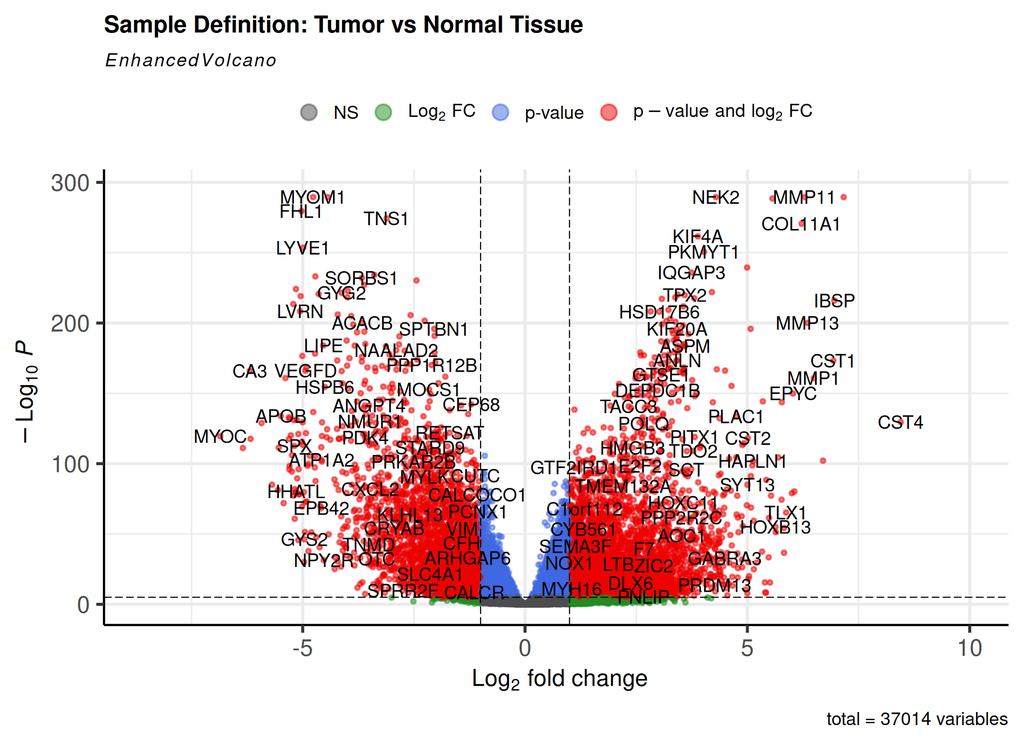

```r
volcano <- EnhancedVolcano(results,
                           lab=results$gene_name,
                           x="log2FoldChange",
                           y="padj",
                           title="Sample Definition: Tumor vs Normal Tissue",
                           pointSize=1.0,
                           labSize=5.0)
print(volcano)
```

```r
figure_path <- "/home1/puyuanli/490_cluster/week7_transcriptomics/brca_tumor_vs_normal_volcano.png"
dir.create(dirname(figure_path), recursive=TRUE, showWarnings=FALSE)
ggplot2::ggsave(filename=figure_path, plot=volcano, width=11, height=8, dpi=300)
cat("Saved volcano plot:", figure_path, "\n")
```

```
Saved volcano plot: /home1/puyuanli/490_cluster/week7_transcriptomics/brca_tumor_vs_normal_volcano.png
```

### Exercise 5 — Interpret the six regions of the volcano plot

The x-axis is log2(Tumor / Normal) fold change; the y-axis is −log10(adjusted p-value). Higher positions indicate stronger statistical significance. The plot uses EnhancedVolcano’s default significance thresholds unless explicitly changed.

- **Top-right:** genes with higher expression in tumors (positive log2 fold change) and statistically significant adjusted p-values; strong candidates for tumor-upregulated genes. Those past both thresholds are highlighted as meeting both criteria.
- **Bottom-right:** genes with higher estimated expression in tumors but weak statistical evidence (larger adjusted p-values); cannot confidently call them differentially expressed.
- **Top-left:** genes with lower expression in tumors (negative log2 fold change; relatively higher in normal tissue) and statistically significant adjusted p-values; candidates for tumor-downregulated genes.
- **Bottom-left:** genes with lower estimated expression in tumors but insufficient statistical evidence for differential expression.
- **Top-middle:** genes with small estimated fold changes near zero but potentially statistically significant adjusted p-values. A statistically significant change need not be large in magnitude.
- **Bottom-middle:** genes with fold changes near zero and non-significant adjusted p-values; no convincing evidence of differential expression.

Note that a gene’s horizontal position alone does not establish significance, and a high position alone does not establish a large effect size. Genes with missing adjusted p-values cannot be interpreted as significant.

### Final verification

```r
stopifnot(file.exists(figure_path),
          file.exists(file.path(analysis_dir, "brca_DESeq_results.csv")),
          file.exists(file.path(analysis_dir, "brca_DESeq_results.rds")),
          identical(rownames(results), rownames(counts_matrix)),
          identical(colnames(counts_matrix), rownames(rna_clinical)))
cat("Notebook output files exist and DESeq2 sample/gene identifiers are aligned.\n")
```

```
Notebook output files exist and DESeq2 sample/gene identifiers are aligned.
```